# BLAST: validation study

Let’s first, we take a look to our samples according to age.

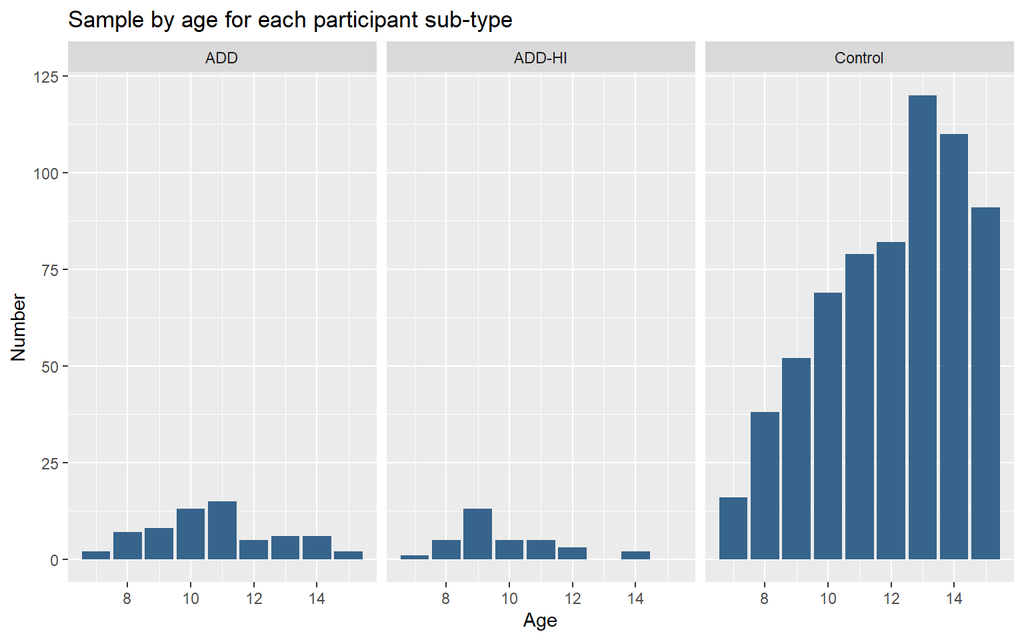

*Samples according to the participant sub-type, by age.*

This graph suggests that :

- Age groups are highly imbalanced, and some ages are even non-existent within the ADD-HI group.

To overcome this issue, age ranges will be used to replace the simple age groups. Based on the available number of participants by age, and the previous findings about attention development during childhood, participants were assigned to 3 different age ranges:

- 7 to 9-years-old
- 10 to 11-years-old
- 12 to 15-years-old

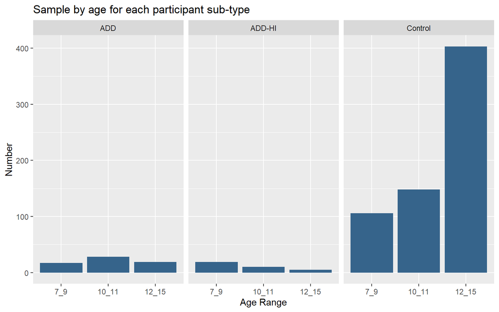

*Samples according to the participant sub-type, by age range.*

Samples between age groups seem now better balanced, especially within the ADHD groups. Though, only a reduced number of participants aged of 12-15yo belong to the ADD-HI category.

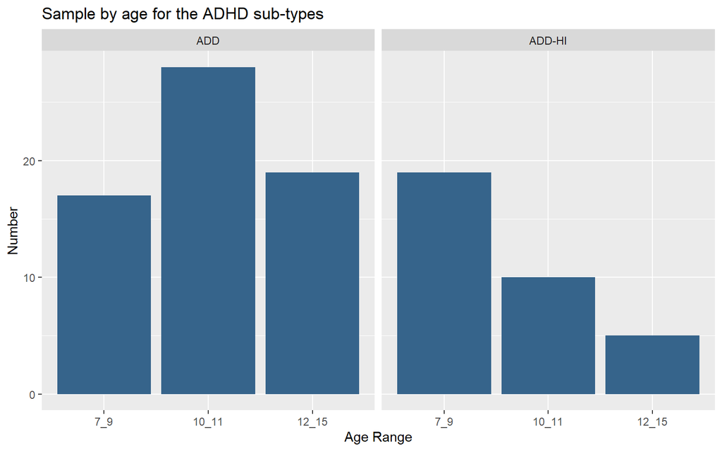

*Samples according to the ADHD sub-types, by age range.*

# RT MEASURES

## Median RT

### Visualization and preprocessing

Summary of the MEDIAN RT variable:

```
##    Min. 1st Qu.  Median    Mean 3rd Qu.    Max.
##   142.0   520.0   620.0   687.9   767.0  3200.0
```

1 participant has a median RT < 150 ms.  
6 participants have a median RT > 2500 ms.

Herein, we considered these participants as outliers and removed them from further analyses.

Total exclusions based on Median RT **n=7**.

New summary of the MEDIAN RT variable:

```
##    Min. 1st Qu.  Median    Mean 3rd Qu.    Max.
##   357.0   519.8   618.5   668.5   763.2  1803.0
```

Data visualization, according to the SUBTYPE, GENDER and HANDEDNESS factors, after outliers removal:

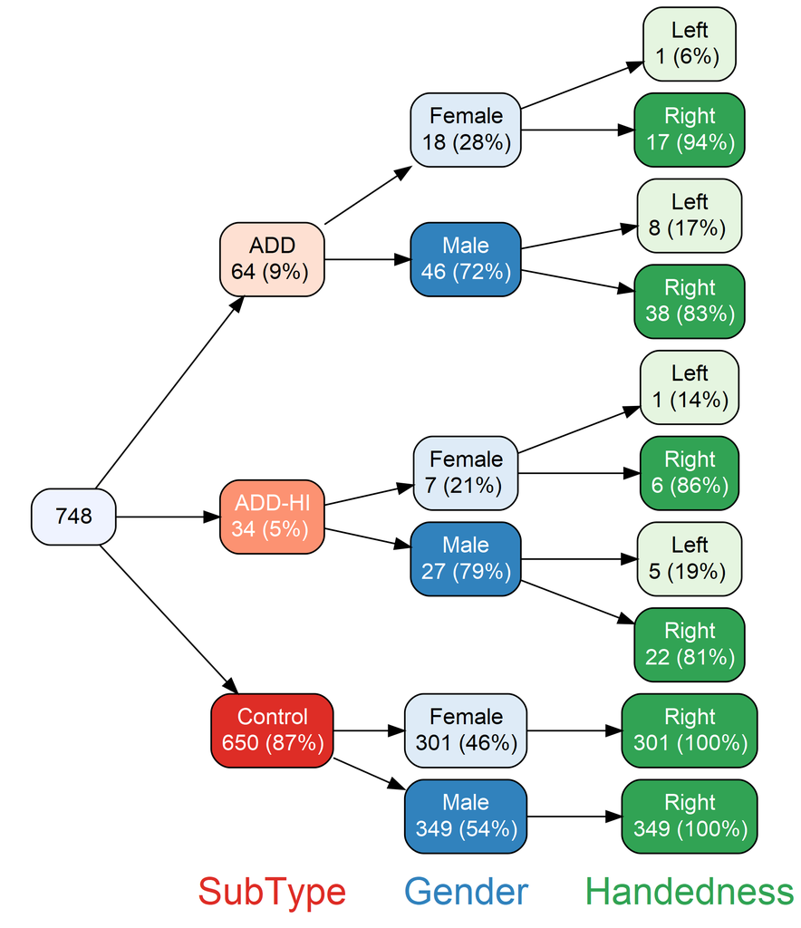

```r
vtree(AllData, c("SubType", "Gender", "Handedness"),
          horiz = TRUE)
```

```r
# grVizToPNG(vtrepng, width=800, folder = GraphSave_path) #to save vtree object
```

*Numbers and percentages of participants according to the participant sub-type, gender and handedness.*

This plot suggests that :

- all the participant from the Cité de la Science (normative data) reported to be right handed (which is highly improbable considering the size of the control group, n=650). Therefore, the HANDEDNESS factor should not be considered in further analyses;
- the GENDER factor levels are quite imbalanced in the ADD-HI group. This needs to be noted if we choose to consider this factor in further analyses.

Now, we check out the distribution of the median RT according to the different participant sub-types (SUBTYPE FACTOR). One color by SUBTYPE level :

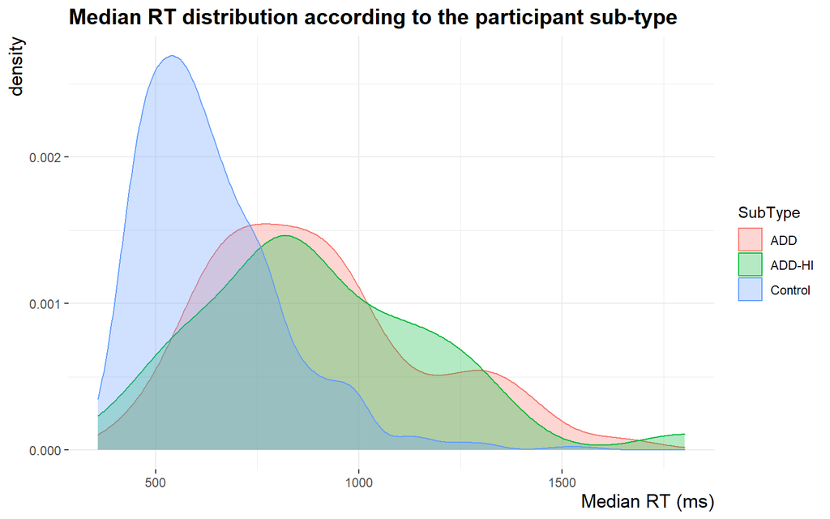

*Median reaction time distribution according to the participant sub-type.*

This plot suggests that :

- the Median RT distributions in ADD and ADD-HI patients are quite similar;
- the Median RT distribution in the Control sub-type is likely to fit a gamma distribution, while the distributions in both the two groups of patients would better fit a Gaussian distribution.

### Median RT modelization and statistics

Note that the HANDEDNESS factor was not considered in analyses (see previous section).

Here, we systematically adopted a threefold approach:

- First: determine which model finely describes the data
- Second: run statistical analysis using the aforementioned best model
- Third: post-hoc analyses

We then now need to find out what could be the best model for the Median RT measure.

```r
# here, Age is a integer variable

model.rt.01 <- glm(MEDIAN_RT_F30_1 ~ Age*Gender*SubType,
                  data = AllData,
                  family = Gamma())

model.rt.02 <- glm(MEDIAN_RT_F30_1 ~ Age*Gender*SubType,
                  data = AllData,
                  family = Gamma(link = "log"))

model.rt.03 <- glm(MEDIAN_RT_F30_1 ~ Age*Gender*SubType,
                  data = AllData,
                  family = gaussian())


model.rt.04 <- glm(MEDIAN_RT_F30_1 ~ Age*Gender*SubType,
                  data = AllData,
                  family = gaussian(link = "log"))

x <- compareGLM(model.rt.01, model.rt.02, model.rt.03, model.rt.04)
x
```

```
## $Models
##   Formula
## 1 "MEDIAN_RT_F30_1 ~ Age * Gender * SubType"
## 2 "MEDIAN_RT_F30_1 ~ Age * Gender * SubType"
## 3 "MEDIAN_RT_F30_1 ~ Age * Gender * SubType"
## 4 "MEDIAN_RT_F30_1 ~ Age * Gender * SubType"
##
## $Fit.criteria
##   Rank Df.res  AIC AICc  BIC McFadden Cox.and.Snell Nagelkerke   p.value
## 1   12    736 9446 9446 9506  0.05339        0.5085     0.5085 0.0003007
## 2   12    736 9453 9454 9513  0.05261        0.5034     0.5034 0.0003376
## 3   12    736 9650 9650 9710  0.04835        0.4799     0.4799 0.0000000
## 4   12    736 9634 9635 9694  0.04987        0.4905     0.4905 0.0000000
```

Let’s then adjust the model (otherwise emmeans’ output can result in NA):

```r
model.rt.01.adj <- glm(MEDIAN_RT_F30_1 ~ Age + Gender + SubType,
                  data = AllData,
                  family = Gamma())
rm(model.rt.01)
```

The model.01 with a Gamma distribution without log transformation looks better than the others models. Now let’s take a look to the details of this model and see if something might be wrong with it.

```r
library(performance)
r2(model.rt.01.adj)
```

```
## # R2 for Generalized Linear Regression
##   Nagelkerke's R2: 0.512
```

The R² seems sufficient.

```r
summ(model.rt.01.adj)
```

| Observations | 748 |
| --- | --- |
| Dependent variable | MEDIAN_RT_F30_1 |
| Type | Generalized linear model |
| Family | Gamma |
| Link | inverse |

| χ²(4) | 31.58 |
| --- | --- |
| Pseudo-R² (Cragg-Uhler) | 0.50 |
| Pseudo-R² (McFadden) | 0.05 |
| AIC | 9437.46 |
| BIC | 9465.16 |

|  | Est. | S.E. | t val. | p |
| --- | --- | --- | --- | --- |
| (Intercept) | -0.00 | 0.00 | -0.74 | 0.46 |
| Age | 0.00 | 0.00 | 21.91 | 0.00 |
| GenderMale | 0.00 | 0.00 | 0.39 | 0.69 |
| SubTypeADD-HI | 0.00 | 0.00 | 1.70 | 0.09 |
| SubTypeControl | 0.00 | 0.00 | 9.82 | 0.00 |

Standard errors: MLE

Now, let’s check how the distribution family is a good fit for our model ([click here for more details about check_distrivution()](https://www.rdocumentation.org/packages/performance/versions/0.7.2/topics/check_distribution) or [here](https://cran.r-project.org/web/packages/performance/performance.pdf))

```
## # Distribution of Model Family
##
## Predicted Distribution of Residuals
##
##  Distribution Probability
##        normal         44%
##          beta         22%
##       tweedie         12%
##
## Predicted Distribution of Response
##
##                Distribution Probability
##  neg. binomial (zero-infl.)         72%
##                   lognormal         22%
##               beta-binomial          6%
```

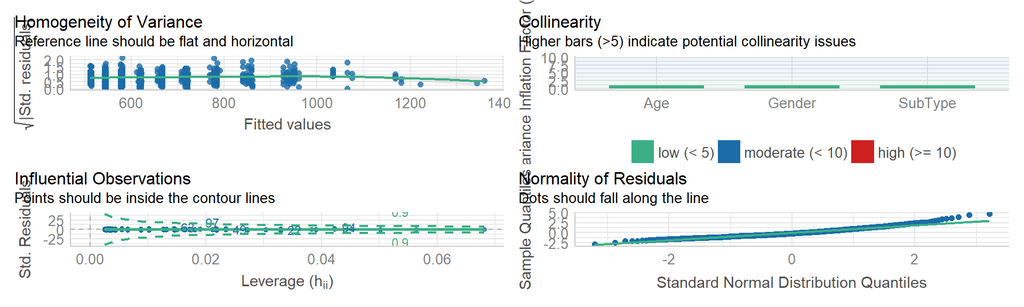

*Visual check of the model.*

After quality check, the model.01 seems to well describe the data, without over fitting.

We can now run a typical variance analysis. For GLM, the Anova function allows to run either likelihood-ratio chisquare test, Wald chisquare test or F-tests. See [here](https://www.rdocumentation.org/packages/car/versions/3.0-11/topics/Anova) for more information.

```r
Anova(model.rt.01.adj, test.statistic = "LR")
```

```
## Analysis of Deviance Table (Type II tests)
##
## Response: MEDIAN_RT_F30_1
##         LR Chisq Df Pr(>Chisq)
## Age       462.31  1     <2e-16 ***
## Gender      0.16  1     0.6934
## SubType   101.92  2     <2e-16 ***
## ---
## Signif. codes:  0 '***' 0.001 '**' 0.01 '*' 0.05 '.' 0.1 ' ' 1
```

> **Note:**

> Here we could also have used “Anova(model.01, test.statistic =”F“)”.

> F-test: method used to jointly test all the covariates, in essence asking whether the model is better than a randomly selected one.

> Likelihood ratio test: is a maximum likelihood test used to compare the likelihoods of two models to see which one is a better explanation of the data.

> Maximum likelihood tests make stronger assumptions and are more efficient in their use of data relative to method of moments tests. In practice it there is not going to be a big difference in results when using either F or MLR test, though likelihood ratio tests are more popular for generically comparing two separate regressions. There is no much point in using an F-test of a single model, whereas the likelihood ratio test can be used for generalized linear models as a replacement for R2 in testing goodness of fit.

**Results from the MEDIAN RT variance analysis show:**

- a main effect of AGE
- a main effect of SUBTYPE

```r
summary(AllData$Age)
```

```
##    Min. 1st Qu.  Median    Mean 3rd Qu.    Max.
##    7.00   10.00   12.00   11.81   14.00   15.00
```

```r
modelrt.ph.subtype_age <- emmeans(model.rt.01.adj, ~ SubType | Age,
                  at = list(Age = c(78, 9, 12)))

pairs(modelrt.ph.subtype_age)
```

```
## Age = 78:
##  contrast            estimate       SE  df z.ratio p.value
##  ADD - (ADD-HI)     -8.35e-05 4.92e-05 Inf  -1.697  0.2065
##  ADD - Control      -3.19e-04 3.24e-05 Inf  -9.822  <.0001
##  (ADD-HI) - Control -2.35e-04 4.30e-05 Inf  -5.461  <.0001
##
## Age =  9:
##  contrast            estimate       SE  df z.ratio p.value
##  ADD - (ADD-HI)     -8.35e-05 4.92e-05 Inf  -1.697  0.2065
##  ADD - Control      -3.19e-04 3.24e-05 Inf  -9.822  <.0001
##  (ADD-HI) - Control -2.35e-04 4.30e-05 Inf  -5.461  <.0001
##
## Age = 12:
##  contrast            estimate       SE  df z.ratio p.value
##  ADD - (ADD-HI)     -8.35e-05 4.92e-05 Inf  -1.697  0.2065
##  ADD - Control      -3.19e-04 3.24e-05 Inf  -9.822  <.0001
##  (ADD-HI) - Control -2.35e-04 4.30e-05 Inf  -5.461  <.0001
##
## Results are averaged over the levels of: Gender
## Note: contrasts are still on the inverse scale
## P value adjustment: tukey method for comparing a family of 3 estimates
```

```r
# modelrt.ph.age = emmeans(model.01.adj, pairwise ~ AgeRange)
# modelrt.ph.age$contrasts
```

**Irrespective of the SUBJECT TYPE, participants are becoming faster to answer the target with increasing age.**

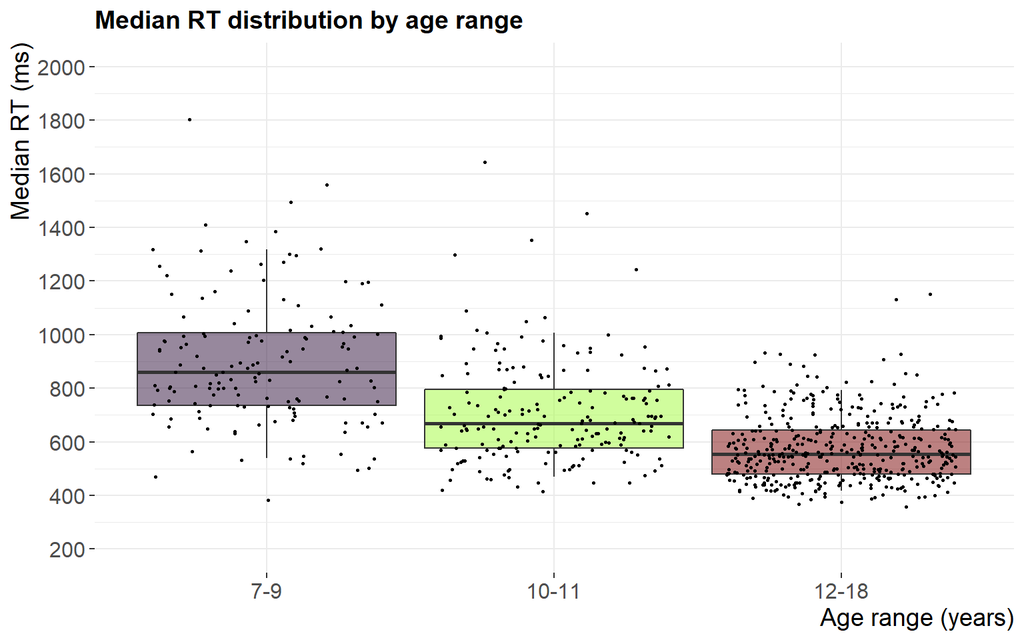

*Median reaction time as a function of the age range. Within each boxplot (Tukey method), the horizontal line represents the mean, the box delineates the area between the first and third quartiles (interquartile range); the vertical line represents the interval between quantile 5 and 90 (i.e., the dispersion of 90% of the population); juxtaposed to each boxplot, the dots represent individual performance.*

Tukey post-hoc analysis for the SUBJECT TYPE effect:

```r
modelrt.ph.subtype = emmeans(model.rt.01.adj, pairwise ~ SubType)
modelrt.ph.subtype$contrasts
```

```
##  contrast            estimate       SE  df z.ratio p.value
##  ADD - (ADD-HI)     -8.35e-05 4.92e-05 Inf  -1.697  0.2065
##  ADD - Control      -3.19e-04 3.24e-05 Inf  -9.822  <.0001
##  (ADD-HI) - Control -2.35e-04 4.30e-05 Inf  -5.461  <.0001
##
## Results are averaged over the levels of: Gender
## Note: contrasts are still on the inverse scale
## P value adjustment: tukey method for comparing a family of 3 estimates
```

**HSD Post-hoc analysis indicates that there is no difference between the 2 group of patients (ADD vs. ADD-HI). However, both the ADD and ADD-HI participants were slower to respond to target in comparison to participants from the Control group.**

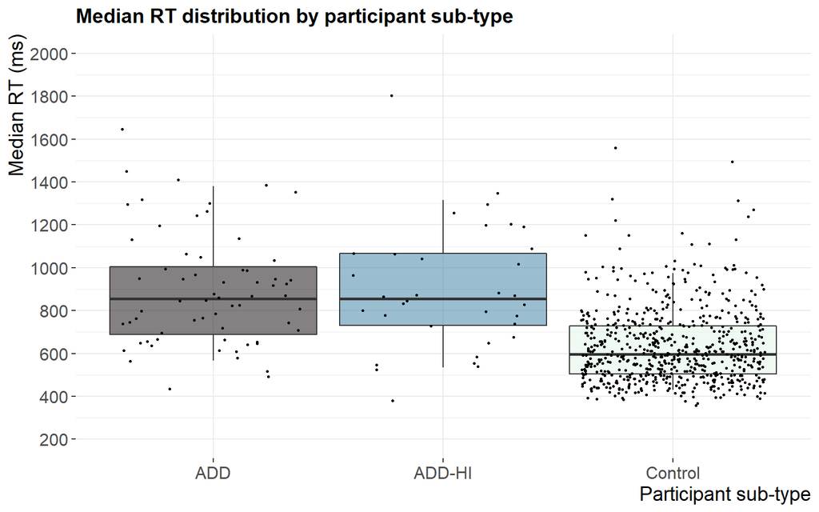

*Median reaction time as a function of the participant sub-type. Within each boxplot (Tukey method), the horizontal line represents the mean, the box delineates the area between the first and third quartiles (interquartile range); the vertical line represents the interval between quantile 5 and 90 (i.e., the dispersion of 90% of the population); juxtaposed to each boxplot, the dots represent individual performance.*

## Mean RT with penalties

### Visualization and preprocessing

Summary of the Mean RT with penalties (MEAN_RT_WPEN) variable:

```
##    Min. 1st Qu.  Median    Mean 3rd Qu.    Max.
##     425     854    1072    1156    1349    4141
```

Possible outliers:

- 38 MEAN TR WPEN > 2000ms (patients + controls)
- 9 MEAN TR WPEN > 2500ms (patients + controls)
- 2 MEAN TR WPEN > 3000ms (patient + control)
- 10 MEAN TR WPEN < 500ms (only controls)

Because I was not sure that could really consider any of the aforementioned performance as pure outliers, I choose to keep all the values for further analysis of MEAN RT WPEN (if necessary, we can discuss this point later).

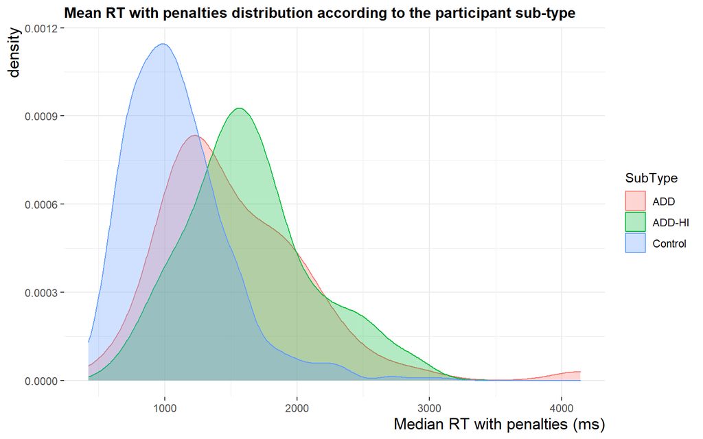

*Mean reaction time with penalties distribution according to the participant sub-type.*

Overall, the MEAN RT WPEN distributions seem to fit a Gamma distribution.

### Modelization and statistics

```r
# here, Age is a integer variable

model.wpen.01 <- glm(MEANTR_WPEN_F30_1 ~ Age*Gender*SubType,
                  data = AllData,
                  family = Gamma())

model.wpen.02 <- glm(MEANTR_WPEN_F30_1 ~ Age*Gender*SubType,
                  data = AllData,
                  family = Gamma(link = "log"))

model.wpen.03 <- glm(MEANTR_WPEN_F30_1 ~ Age*Gender*SubType,
                  data = AllData,
                  family = gaussian())


model.wpen.04 <- glm(MEANTR_WPEN_F30_1 ~ Age*Gender*SubType,
                  data = AllData,
                  family = gaussian(link = "log"))

x <- compareGLM(model.wpen.01, model.wpen.02, model.wpen.03, model.wpen.04)
x[["Fit.criteria"]]
```

```
##   Rank Df.res   AIC  AICc   BIC McFadden Cox.and.Snell Nagelkerke   p.value
## 1   12    736 10810 10810 10870  0.02519        0.3111     0.3111 0.0006098
## 2   12    736 10820 10820 10880  0.02501        0.3093     0.3093 0.0006490
## 3   12    736 10980 10980 11040  0.02439        0.3067     0.3067 0.0000000
## 4   12    736 10980 10980 11040  0.02489        0.3118     0.3118 0.0000000
```

```r
x$Fit.criteria
```

```
##   Rank Df.res   AIC  AICc   BIC McFadden Cox.and.Snell Nagelkerke   p.value
## 1   12    736 10810 10810 10870  0.02519        0.3111     0.3111 0.0006098
## 2   12    736 10820 10820 10880  0.02501        0.3093     0.3093 0.0006490
## 3   12    736 10980 10980 11040  0.02439        0.3067     0.3067 0.0000000
## 4   12    736 10980 10980 11040  0.02489        0.3118     0.3118 0.0000000
```

The model.wpen.01 with a Gamma distribution without log transformation looks better than the others models. Now let’s take a look to the details of this model and see if something might be wrong with it.

Let’s then adjust the model:

```r
Anova(model.wpen.01, test.statistic = "LR")
```

```
## Analysis of Deviance Table (Type II tests)
##
## Response: MEANTR_WPEN_F30_1
##                    LR Chisq Df Pr(>Chisq)
## Age                 173.872  1  < 2.2e-16 ***
## Gender                0.047  1     0.8282
## SubType              57.402  2   3.43e-13 ***
## Age:Gender            1.787  1     0.1813
## Age:SubType           0.420  2     0.8107
## Gender:SubType        0.329  2     0.8482
## Age:Gender:SubType    1.136  2     0.5667
## ---
## Signif. codes:  0 '***' 0.001 '**' 0.01 '*' 0.05 '.' 0.1 ' ' 1
```

```r
model.wpen.01.adj <- glm(MEANTR_WPEN_F30_1 ~ Age + Gender + SubType,
                  data = AllData,
                  family = Gamma())
rm(model.wpen.01)
```

```r
library(performance)
r2(model.wpen.01.adj)
```

```
## # R2 for Generalized Linear Regression
##   Nagelkerke's R2: 0.316
```

The R² is seems okay but it is not that much important.

```r
summ(model.wpen.01.adj)
```

| Observations | 748 |
| --- | --- |
| Dependent variable | MEANTR_WPEN_F30_1 |
| Type | Generalized linear model |
| Family | Gamma |
| Link | inverse |

| χ²(4) | 29.44 |
| --- | --- |
| Pseudo-R² (Cragg-Uhler) | 0.31 |
| Pseudo-R² (McFadden) | 0.02 |
| AIC | 10804.05 |
| BIC | 10831.75 |

|  | Est. | S.E. | t val. | p |
| --- | --- | --- | --- | --- |
| (Intercept) | 0.00 | 0.00 | 0.67 | 0.50 |
| Age | 0.00 | 0.00 | 13.46 | 0.00 |
| GenderMale | 0.00 | 0.00 | 0.12 | 0.91 |
| SubTypeADD-HI | 0.00 | 0.00 | 0.22 | 0.83 |
| SubTypeControl | 0.00 | 0.00 | 6.85 | 0.00 |

Standard errors: MLE

Now, let’s check if the distribution family is a good fit for our model.

```
## # Distribution of Model Family
##
## Predicted Distribution of Residuals
##
##  Distribution Probability
##        normal         59%
##       tweedie         22%
##          beta         12%
##
## Predicted Distribution of Response
##
##                Distribution Probability
##  neg. binomial (zero-infl.)         62%
##                   lognormal         31%
##               beta-binomial          6%
```

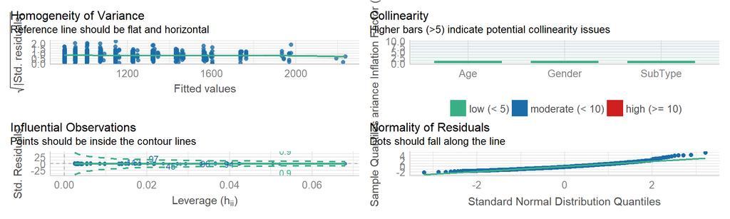

*Visual check of the model.*

After quality check, the model.wpen.01 seems to adequately describe the data, without over fitting.

We can now run a variance analysis.

```r
Anova(model.wpen.01.adj, test.statistic = "LR")
```

```
## Analysis of Deviance Table (Type II tests)
##
## Response: MEANTR_WPEN_F30_1
##         LR Chisq Df Pr(>Chisq)
## Age      175.264  1  < 2.2e-16 ***
## Gender     0.013  1     0.9076
## SubType   57.658  2  3.018e-13 ***
## ---
## Signif. codes:  0 '***' 0.001 '**' 0.01 '*' 0.05 '.' 0.1 ' ' 1
```

**Results from the MEAN RT WPEN variance analysis show:**

- a main effect of AGE
- a main effect of SUBTYPE

Tukey post-hoc analysis for the SUBJECT TYPE effect:

```r
modelrtwpen.ph.subtype = emmeans(model.wpen.01.adj, pairwise ~ SubType)
modelrtwpen.ph.subtype$contrasts
```

```
##  contrast            estimate       SE  df z.ratio p.value
##  ADD - (ADD-HI)     -8.91e-06 4.08e-05 Inf  -0.218  0.9740
##  ADD - Control      -1.91e-04 2.79e-05 Inf  -6.846  <.0001
##  (ADD-HI) - Control -1.82e-04 3.52e-05 Inf  -5.168  <.0001
##
## Results are averaged over the levels of: Gender
## Note: contrasts are still on the inverse scale
## P value adjustment: tukey method for comparing a family of 3 estimates
```

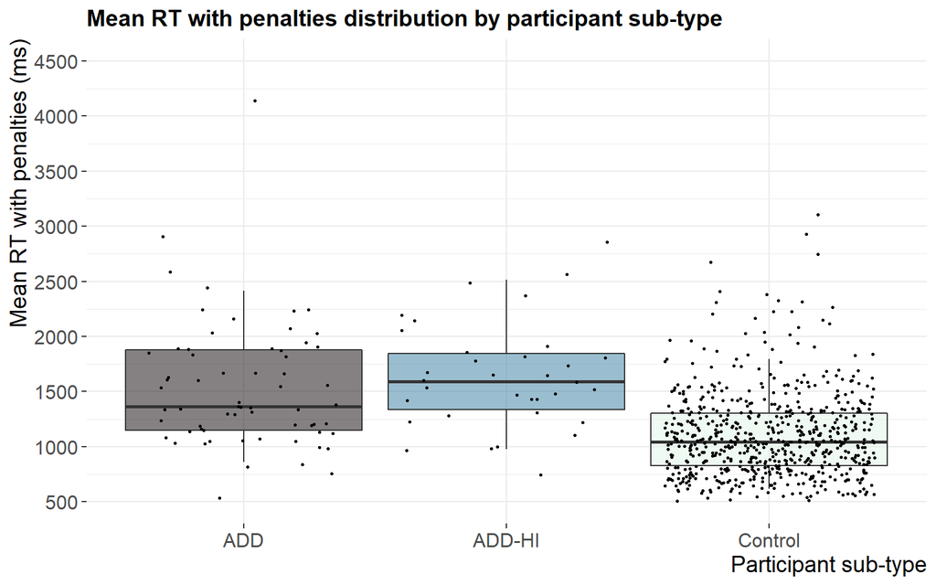

*Mean reaction time with penalties as a function of the participant sub-type. Within each boxplot (Tukey method), the horizontal line represents the mean, the box delineates the area between the first and third quartiles (interquartile range); the vertical line represents the interval between quantile 5 and 90 (i.e., the dispersion of 90% of the population); juxtaposed to each boxplot, the dots represent individual performance.*

# RESPONSE TYPES

## Intensity scores

### Visualization and preprocessing

Summary of PCT_3000 response variable (index of intensity):

```
##    Min. 1st Qu.  Median    Mean 3rd Qu.    Max.
##    0.00   30.75   46.00   45.13   60.00   92.00
```

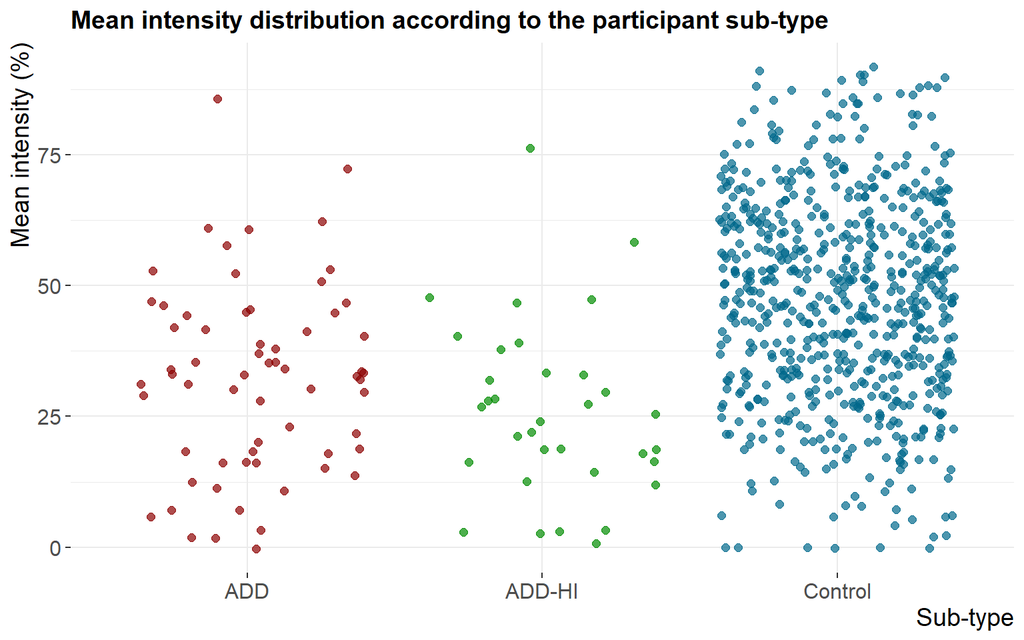

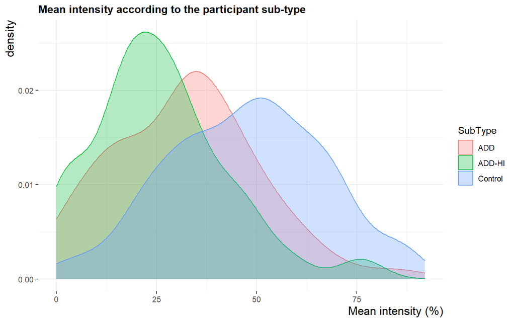

### Modelization and statistics

Please, note that the model using a gamma log distribution do no work. The error message is mentionned in the code below.

```r
AllData$PCT3000_F30_1 = AllData$PCT3000_F30_1 + 0.000001


model.int.01 <- glm(PCT3000_F30_1 ~ Age*Gender*SubType,
                  data = AllData,
                  family = Gamma())

# DOES NOT WORK : Error: inner loop 1; cannot correct step size

# model.int.02 <- glm(PCT3000_F30_1 ~ Age*Gender*SubType,
#                   data = AllData,
#                   family = Gamma(link = "log"))

model.int.03 <- glm(PCT3000_F30_1 ~ Age*Gender*SubType,
                  data = AllData,
                  family = gaussian())


model.int.04 <- glm(PCT3000_F30_1 ~ Age*Gender*SubType,
                  data = AllData,
                  family = gaussian(link = "log"))

x <- compareGLM(model.int.01, model.int.03, model.int.04)
x[["Fit.criteria"]]
```

```
##   Rank Df.res  AIC AICc  BIC McFadden Cox.and.Snell Nagelkerke   p.value
## 1   12    736 7025 7026 7085 0.007911        0.0719     0.0719 0.0008408
## 2   12    736 6509 6510 6569 0.019770        0.1604     0.1604 0.0000000
## 3   12    736 6510 6511 6570 0.019630        0.1593     0.1593 0.0000000
```

The best model is the one using a Gaussian distribution without log transformation.

```r
rm(model.int.01, model.int.04)
```

Let’s then adjust the model:

```r
Anova(model.int.03, test.statistic = "LR")
```

```
## Analysis of Deviance Table (Type II tests)
##
## Response: PCT3000_F30_1
##                    LR Chisq Df Pr(>Chisq)
## Age                  59.872  1  1.012e-14 ***
## Gender                0.752  1     0.3860
## SubType              40.683  2  1.465e-09 ***
## Age:Gender            0.159  1     0.6901
## Age:SubType           0.245  2     0.8846
## Gender:SubType        0.826  2     0.6616
## Age:Gender:SubType    0.905  2     0.6362
## ---
## Signif. codes:  0 '***' 0.001 '**' 0.01 '*' 0.05 '.' 0.1 ' ' 1
```

```r
model.int.03.adj <- glm(PCT3000_F30_1 ~ Age + Gender + SubType,
                  data = AllData,
                  family = gaussian())
rm(model.int.03)
```

```r
library(performance)
r2(model.int.03.adj)
```

```
##   R2: 0.158
```

The R² is seems not really okay. We should discuss this value.

```r
summ(model.int.03.adj)
```

| Observations | 748 |
| --- | --- |
| Dependent variable | PCT3000_F30_1 |
| Type | Linear regression |

| χ²(4) | 47912.41 |
| --- | --- |
| Pseudo-R² (Cragg-Uhler) | 0.16 |
| Pseudo-R² (McFadden) | 0.02 |
| AIC | 6497.51 |
| BIC | 6525.21 |

|  | Est. | S.E. | t val. | p |
| --- | --- | --- | --- | --- |
| (Intercept) | 6.76 | 4.25 | 1.59 | 0.11 |
| Age | 2.44 | 0.31 | 7.80 | 0.00 |
| GenderMale | -1.17 | 1.38 | -0.85 | 0.40 |
| SubTypeADD-HI | -3.83 | 3.95 | -0.97 | 0.33 |
| SubTypeControl | 11.89 | 2.47 | 4.81 | 0.00 |

Standard errors: MLE

Now, let’s check if the distribution family is a good fit for our model.

–> MODEL DIAGNOSTIC NOT POSSIBLE: RETURNS THE FOLOWING ERROR: Error in grid.Call(C_convert, x, as.integer(whatfrom), as.integer(whatto),: Le zone active (Viewport) a des dimensions nulles

```
## # Distribution of Model Family
##
## Predicted Distribution of Residuals
##
##  Distribution Probability
##        normal         66%
##       tweedie         22%
##       weibull          6%
##
## Predicted Distribution of Response
##
##                Distribution Probability
##               beta-binomial         28%
##                     tweedie         22%
##  neg. binomial (zero-infl.)         16%
```

We can now run a variance analysis.

```r
Anova(model.int.03.adj, test.statistic = "LR")
```

```
## Analysis of Deviance Table (Type II tests)
##
## Response: PCT3000_F30_1
##         LR Chisq Df Pr(>Chisq)
## Age       60.807  1  6.296e-15 ***
## Gender     0.719  1     0.3965
## SubType   40.875  2  1.331e-09 ***
## ---
## Signif. codes:  0 '***' 0.001 '**' 0.01 '*' 0.05 '.' 0.1 ' ' 1
```

- a main effect of AGE
- a main effect of SUBTYPE

Tukey post-hoc analysis for the SUBJECT TYPE effect:

```r
modelint.ph.subtype = emmeans(model.int.03.adj, pairwise ~ SubType)
modelint.ph.subtype$contrasts
```

```
##  contrast           estimate   SE  df z.ratio p.value
##  ADD - (ADD-HI)         3.83 3.95 Inf   0.971  0.5955
##  ADD - Control        -11.89 2.47 Inf  -4.814  <.0001
##  (ADD-HI) - Control   -15.72 3.35 Inf  -4.694  <.0001
##
## Results are averaged over the levels of: Gender
## P value adjustment: tukey method for comparing a family of 3 estimates
```

**HSD Post-hoc analysis indicates that there both ADD and ADD-HI patients had lower intensity scores than participants from the control group.**

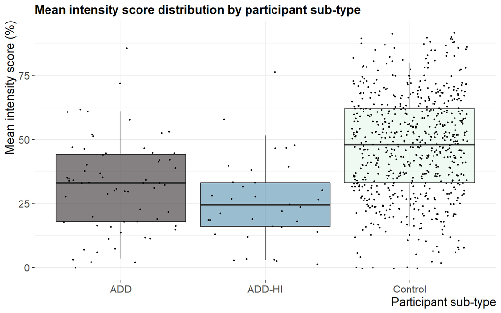

*Mean intensity score as a function of the participant sub-type. Within each boxplot (Tukey method), the horizontal line represents the mean, the box delineates the area between the first and third quartiles (interquartile range); the vertical line represents the interval between quantile 5 and 90 (i.e., the dispersion of 90% of the population); juxtaposed to each boxplot, the dots represent individual performance.*

## Stability

### Visualization and preprocessing

Summary of PCT_40 response variable (index of stability):

```
##    Min. 1st Qu.  Median    Mean 3rd Qu.    Max.
##    0.00   10.00   19.00   20.67   30.00   66.00
```

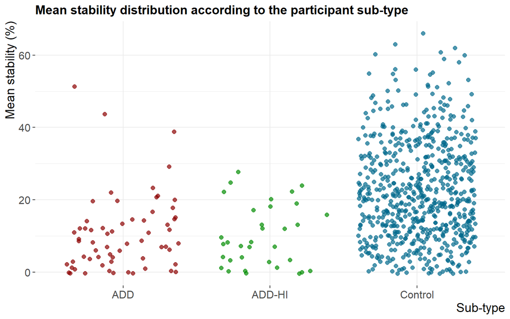

[figure not shown]

### Modelization and statistics

Please, note that the model using a gamma log distribution do no work. The error message is mentionned in the code below.

```r
AllData$PCT40_F30_1 = AllData$PCT40_F30_1 + 0.000001


model.sta.01 <- glm(PCT40_F30_1 ~ Age*Gender*SubType,
                  data = AllData,
                  family = Gamma())

# DOES NOT WORK : Error: inner loop 1; cannot correct step size

# model.sta.02 <- glm(PCT3000_F30_1 ~ Age*Gender*SubType,
#                   data = AllData,
#                   family = Gamma(link = "log"))

model.sta.03 <- glm(PCT40_F30_1 ~ Age*Gender*SubType,
                  data = AllData,
                  family = gaussian())


model.sta.04 <- glm(PCT40_F30_1 ~ Age*Gender*SubType,
                  data = AllData,
                  family = gaussian(link = "log"))

x <- compareGLM(model.sta.01, model.sta.03, model.sta.04)
x[["Fit.criteria"]]
```

```
##   Rank Df.res  AIC AICc  BIC McFadden Cox.and.Snell Nagelkerke   p.value
## 1   12    736 5970 5971 6030 0.007222       0.05617    0.05619 1.681e-08
## 2   12    736 5963 5963 6023 0.016880       0.12740    0.12740 0.000e+00
## 3   12    736 5963 5964 6023 0.016800       0.12680    0.12680 0.000e+00
```

The best model is the one using a Gaussian distribution without log transformation.

```r
rm(model.int.01, model.int.04)
```

Let’s then adjust the model:

```r
Anova(model.sta.03, test.statistic = "LR")
```

```
## Analysis of Deviance Table (Type II tests)
##
## Response: PCT40_F30_1
##                    LR Chisq Df Pr(>Chisq)
## Age                  31.170  1  2.364e-08 ***
## Gender                1.901  1     0.1680
## SubType              44.494  2  2.179e-10 ***
## Age:Gender            0.208  1     0.6480
## Age:SubType           0.235  2     0.8893
## Gender:SubType        0.132  2     0.9360
## Age:Gender:SubType    0.340  2     0.8437
## ---
## Signif. codes:  0 '***' 0.001 '**' 0.01 '*' 0.05 '.' 0.1 ' ' 1
```

```r
model.sta.03.adj <- glm(PCT40_F30_1 ~ Age+Gender+SubType,
                  data = AllData,
                  family = gaussian())
rm(model.int.03)
```

```r
library(performance)
r2(model.int.03.adj)
```

[output not shown]

The R² is seems not really okay.

We should discuss this value.

```r
summ(model.int.03.adj)
```

[output not shown]

| χ²(4) | 47912.41 |
| --- | --- |
| Pseudo-R² (Cragg-Uhler) | 0.16 |
| Pseudo-R² (McFadden) | 0.02 |
| AIC | 6497.51 |
| BIC | 6525.21 |

|  | Est. | S.E. | t val. | p |
| --- | --- | --- | --- | --- |
| (Intercept) | 6.76 | 4.25 | 1.59 | 0.11 |
| Age | 2.44 | 0.31 | 7.80 | 0.00 |
| GenderMale | -1.17 | 1.38 | -0.85 | 0.40 |
| SubTypeADD-HI | -3.83 | 3.95 | -0.97 | 0.33 |
| SubTypeControl | 11.89 | 2.47 | 4.81 | 0.00 |

Standard errors: MLE

Now, let’s check if the distribution family is a good fit for our model.

–> MODEL DIAGNOSTIC NOT POSSIBLE, SAME ERROR FOUND FOR THE INTENSITY MODEL.

```
## # Distribution of Model Family
##
## Predicted Distribution of Residuals
##
##  Distribution Probability
##        normal         66%
##       tweedie         22%
##       weibull          6%
##
## Predicted Distribution of Response
##
##                Distribution Probability
##               beta-binomial         28%
##                     tweedie         22%
##  neg. binomial (zero-infl.)         16%
```

We can now run a variance analysis.

```r
Anova(model.int.03.adj, test.statistic = "LR")
```

[output not shown]

- a main effect of AGE
- a main effect of SUBTYPE

Tukey post-hoc analysis for the SUBJECT TYPE effect:

```r
modelint.ph.subtype = emmeans(model.int.03.adj, pairwise ~ SubType)
modelint.ph.subtype$contrasts
```

[output not shown]

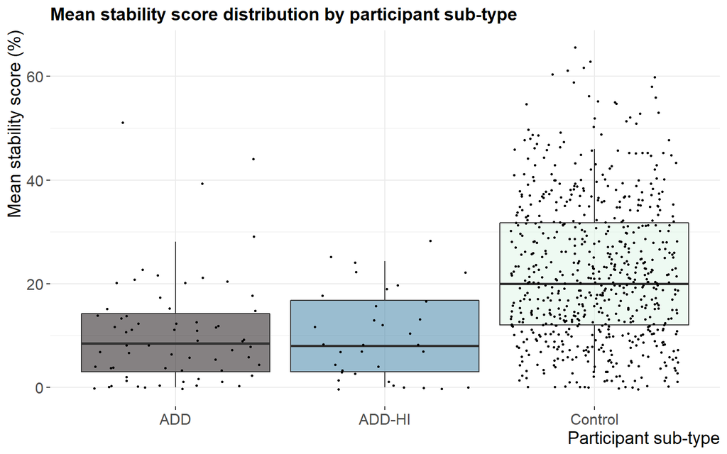

*Mean stability score as a function of the participant sub-type. Within each boxplot (Tukey method), the horizontal line represents the mean, the box delineates the area between the first and third quartiles (interquartile range); the vertical line represents the interval between quantile 5 and 90 (i.e., the dispersion of 90% of the population); juxtaposed to each boxplot, the dots represent individual performance.*

NEXT: SAMPLE SIZE CALCULATION https://www.r-bloggers.com/2017/07/power-analysis-and-sample-size-calculation-for-agriculture/